# Analysis of Pierce County House Sales

### B) Sale Price and Year Built

- Next, we will view the association between the time the house was built and Sale Price.

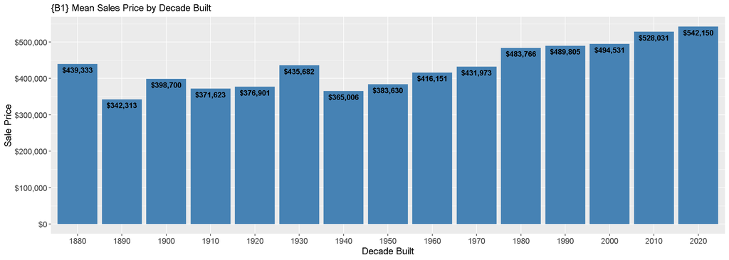

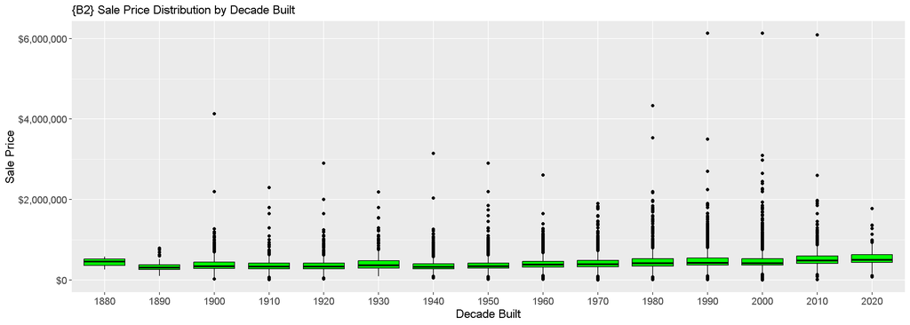

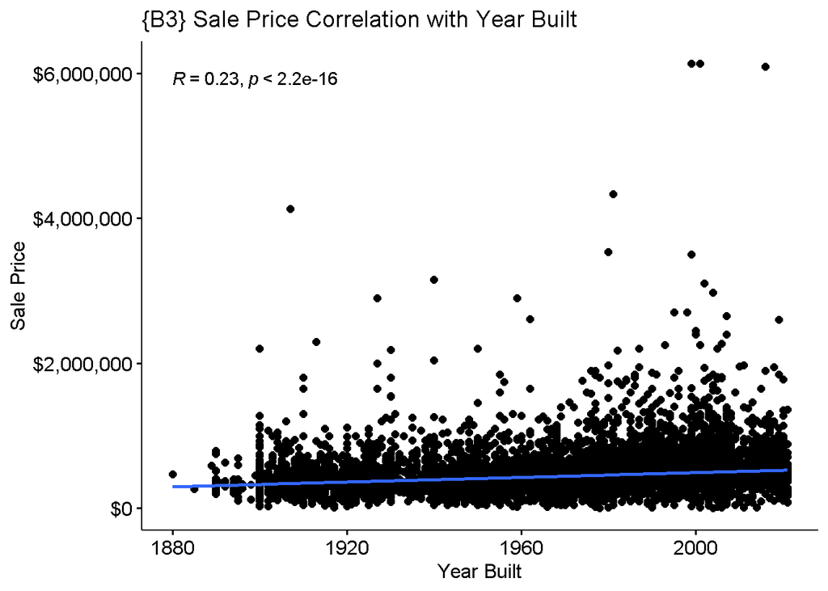

{B4} Summary Statistics for Sale Price by Decade Built

| Decade Built | Count | Mean Sale Price | Median Sale Price | SD of Sale Price | Min Sale Price | Max Sale Price |
| --- | --- | --- | --- | --- | --- | --- |
| 1880 | 3 | 439333 | 468000 | 161914 | 265000 | 585000 |
| 1890 | 56 | 342313 | 315625 | 140248 | 101951 | 795000 |
| 1900 | 552 | 398700 | 349475 | 251145 | 25000 | 4126500 |
| 1910 | 556 | 371623 | 335000 | 192131 | 12000 | 2300000 |
| 1920 | 798 | 376901 | 340000 | 200241 | 30000 | 2900000 |
| 1930 | 302 | 435682 | 369000 | 251970 | 92500 | 2185000 |
| 1940 | 965 | 365006 | 330000 | 194117 | 50000 | 3150000 |
| 1950 | 1056 | 383630 | 350000 | 198743 | 20000 | 2900000 |
| 1960 | 1199 | 416151 | 385000 | 177965 | 22000 | 2609788 |
| 1970 | 1509 | 431973 | 399800 | 190875 | 2000 | 1900000 |
| 1980 | 1264 | 483766 | 419725 | 295780 | 10000 | 4334100 |
| 1990 | 2228 | 489805 | 431150 | 249578 | 12752 | 6130000 |
| 2000 | 2776 | 494531 | 425000 | 262619 | 2000 | 6130000 |
| 2010 | 2319 | 528031 | 490000 | 237335 | 10000 | 6090000 |
| 2020 | 1231 | 542150 | 508620 | 159584 | 80000 | 1775000 |

### C) Sale Price and Number of Bedrooms

- Lastly, we will view the association between Number of Bedrooms and Sale Price. Let us find the summary statistics for Bedrooms in relation to Sale Price.

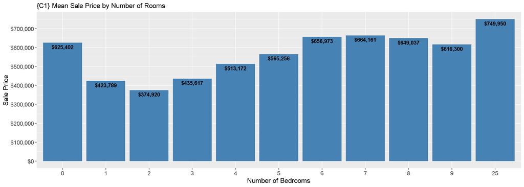

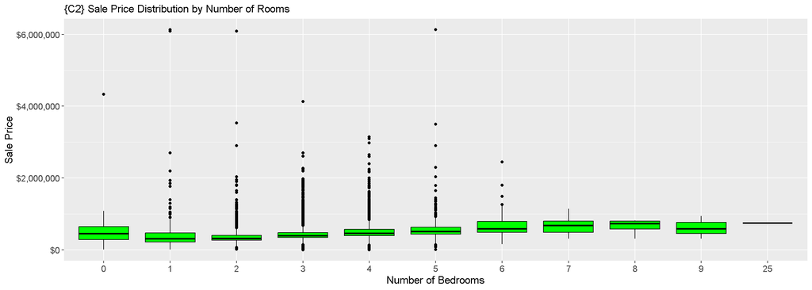

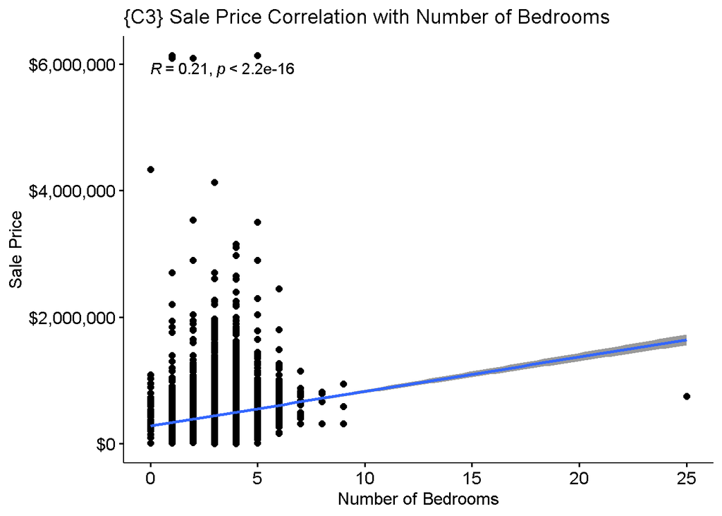

{C4} Summary Statistics for Sale Price by Number of Bedrooms

| Bedrooms | Count | Mean Sale Price | Median Sale Price | SD of Sale Price | Min Sale Price | Max Sale Price |
| --- | --- | --- | --- | --- | --- | --- |
| 0 | 47 | 625402 | 459000 | 826819 | 12510 | 4334100 |
| 1 | 337 | 423789 | 312500 | 537333 | 10000 | 6130000 |
| 2 | 1900 | 374920 | 324995 | 255351 | 22000 | 6090000 |
| 3 | 8504 | 435617 | 398000 | 189366 | 2000 | 4126500 |
| 4 | 4858 | 513172 | 465000 | 217712 | 2000 | 3150000 |
| 5 | 1028 | 565256 | 512922 | 291257 | 12752 | 6130000 |
| 6 | 113 | 656973 | 587450 | 303596 | 162000 | 2450000 |
| 7 | 19 | 664161 | 679000 | 204336 | 316000 | 1147500 |
| 8 | 4 | 649037 | 730000 | 231370 | 317150 | 819000 |
| 9 | 3 | 616300 | 590000 | 315273 | 315000 | 943900 |
| 25 | 1 | 749950 | 749950 | NA | 749950 | 749950 |

### Can Sale Price be predicted?

Based on the data from graphs A - C, sale price can be predicted to a certain extent using variables such as house square footage, year built, and number of bedrooms.

[output not shown]

Thus, while it is possible to predict sale price based on these factors, outliers and additional variables (e.g., location, historical significance, or amenities) likely play a significant role in the final sale price.

## Part 2:

Is missingness informative? Create a binary variable that indicates whether the view quality is missing. Missing values in this data file are represented as an empty character string; that is, `’. Choose three variables. (They may, but do not need to be, the same variables from part 1.) Explore the association between these variables and the binary variable that you created. Follow the same instructions as in Part 1.

Correlation of Variables for Has View Quality

|  | Has View Quality | Sale Price | House Square Feet | Has Waterfront |
| --- | --- | --- | --- | --- |
| Correlation | 1 | 0.2391971 | 0.1353988 | -0.0340727 |

### D) Presence of View Quality and Sale Price

- First, we will analyze ‘sale_price’, the variable with the highest correlation (~0.24) to ‘has_view_quality’.

{D1} Summary Statistics for Has View Quality by Sale Price

| Has View Quality | Count | Mean Sale Price | Median Sale Price | SD of Sale Price | Min Sale Price | Max Sale Price |
| --- | --- | --- | --- | --- | --- | --- |
| 0 | 15895 | 447655 | 410000 | 225581 | 2000 | 6130000 |
| 1 | 919 | 696077 | 665000 | 285186 | 12752 | 2600000 |

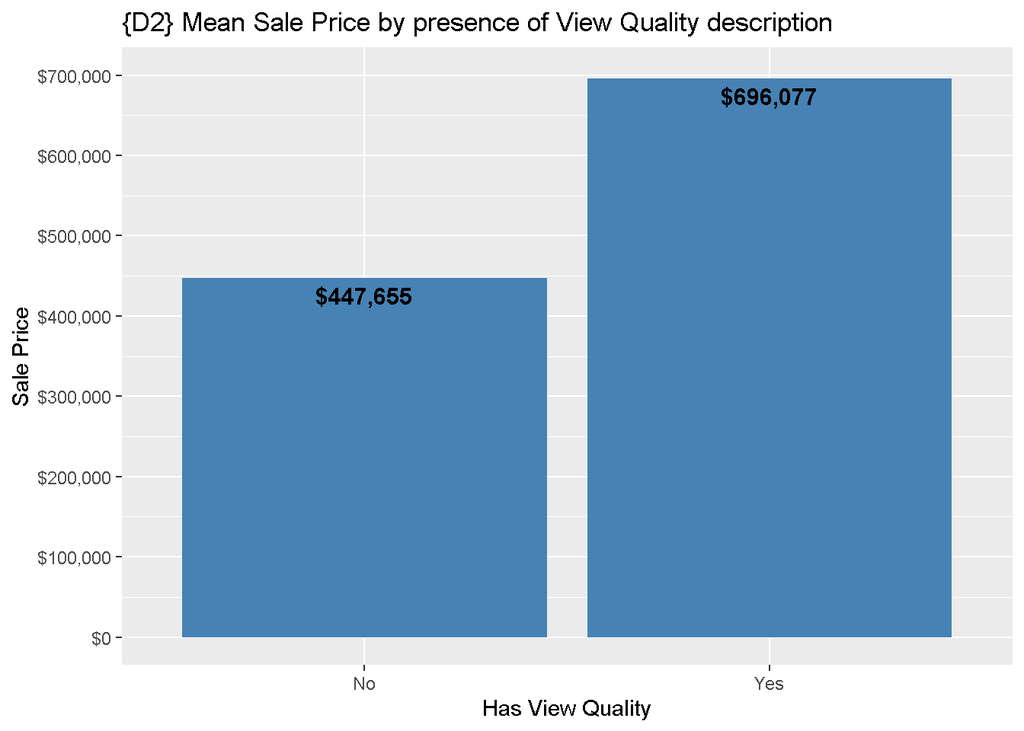

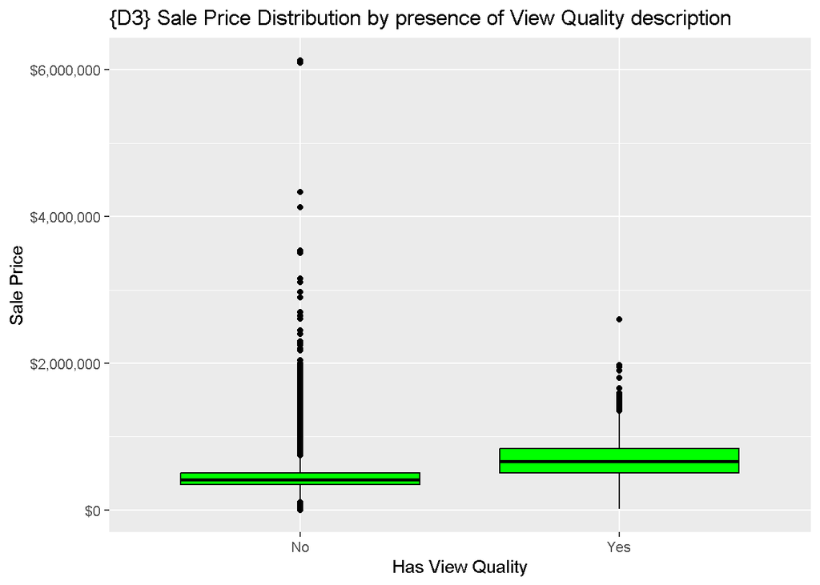

### E) Presence of View Quality and House Square Footage

- Analyzing association between House square footage and presence of view quality description.

{E1} Summary Statistics for Has View Quality by Square Feet

| Has View Quality | Count | Mean Square Feet | Median Square Feet | SD of Square Feet | Min Square Feet | Max Square Feet |
| --- | --- | --- | --- | --- | --- | --- |
| 0 | 15895 | 1855 | 1756 | 743 | 200 | 9510 |
| 1 | 919 | 2308 | 2213 | 912 | 1 | 6295 |

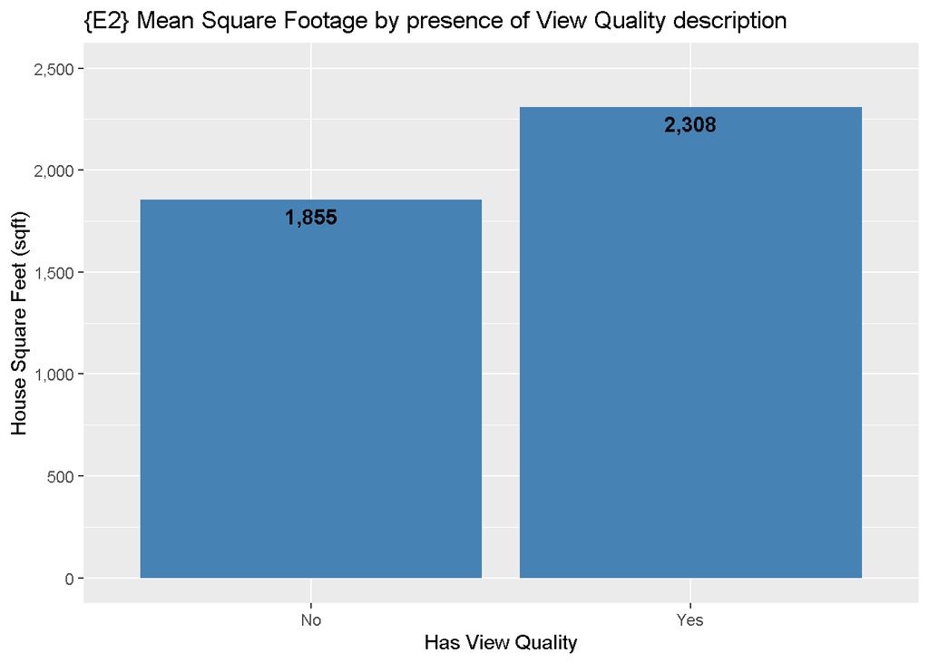

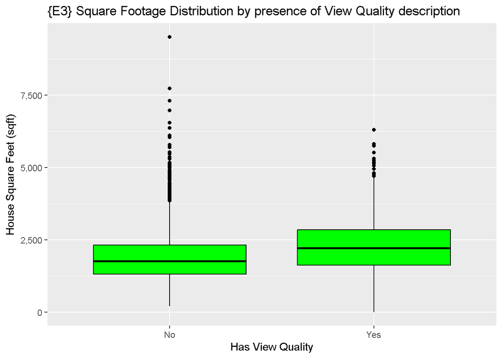

- From our graph {E2}, we can observe a very slight correlation between the presence of view quality and square footage, with homes containing view quality data being approximately 1.24 times larger than those without a view quality description. This is reflected in our Pearson Correlation Coefficient, calculated to be 0.1353988.
- Outliers can be detected in the data. For homes without view quality data, the mean square footage is 1,855 sqft; however, this group also contains properties as large as 9,510 sqft {E1}. Similarly, outliers are present in the group of homes with view quality data, which has a mean size of 2,308 sqft but includes values as low as 1 sqft {E1}. Both of these outliers affect our analysis by lowering the Pearson Correlation Coefficient; however, due to the size of both groups, these outliers are less impactful.

### F) Presence of View Quality and Presence of Waterfront

- Analyzing association between presence of view quality description and presence of a waterfront.

{F1} Cross Table of Frequency for View Quality and existance of a Waterfront

| Has View Quality (0=no, 1=yes) | Has Waterfront (0=no, 1=yes) | Frequency |
| --- | --- | --- |
| 0 | 0 | 15349 |
| 0 | 1 | 546 |
| 1 | 0 | 912 |
| 1 | 1 | 7 |

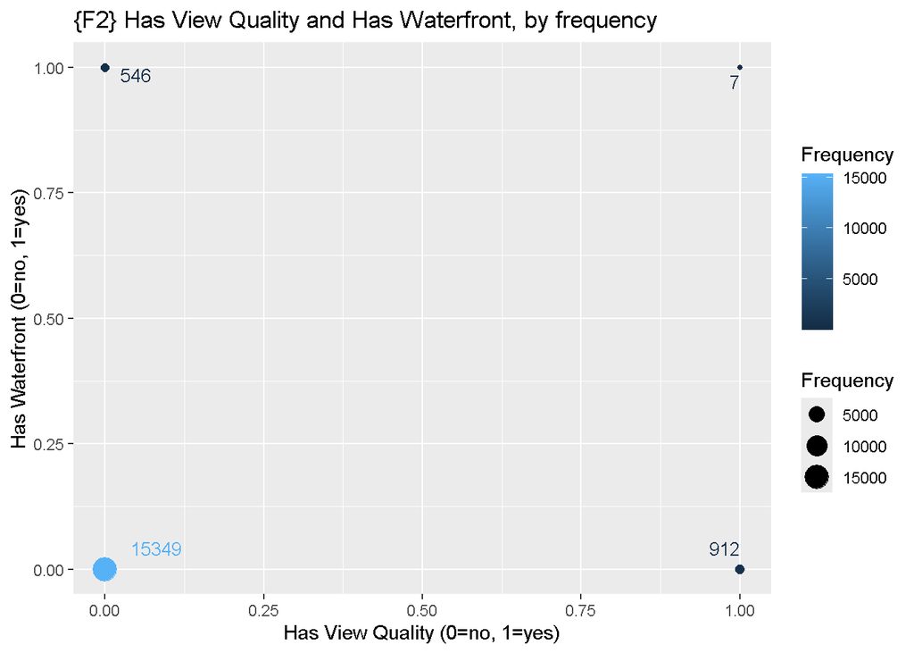

- The association between the presence of view quality and waterfront is minimal. From table {F1}, we see that the vast majority of homes without waterfront access also lack a view quality designation (15,349 homes). Only a small number of properties have both waterfront and view quality (7 homes). This suggests that while there is some overlap, view quality and waterfront presence are largely independent features. This is further confirmed by our Pearson Correlation Coefficient of -0.0340727.

### Is missingness informative?

Missingness in “view_quality” proves to be informative based on data from tables and graphs D - F.

[output not shown]

Thus, the missingness of “view_quality” data provides valuable information, potentially signaling homes with fewer premium features.